# Forecasting 2024 Global Happiness Trends: Exploring the Impact of Cumulative Socio-Economic Influences

### Model Testing

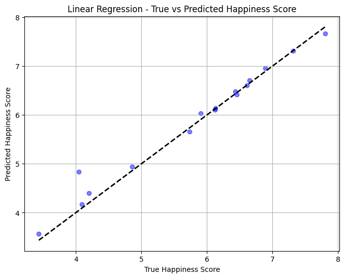

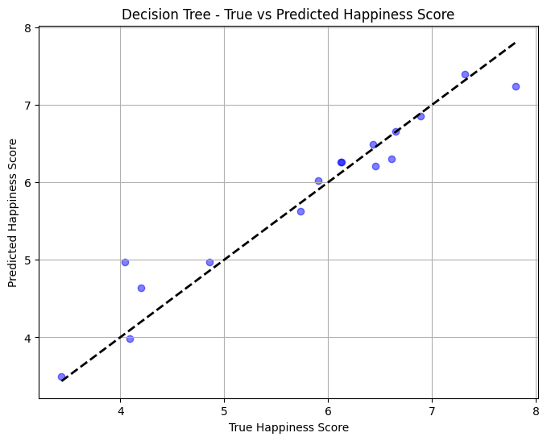

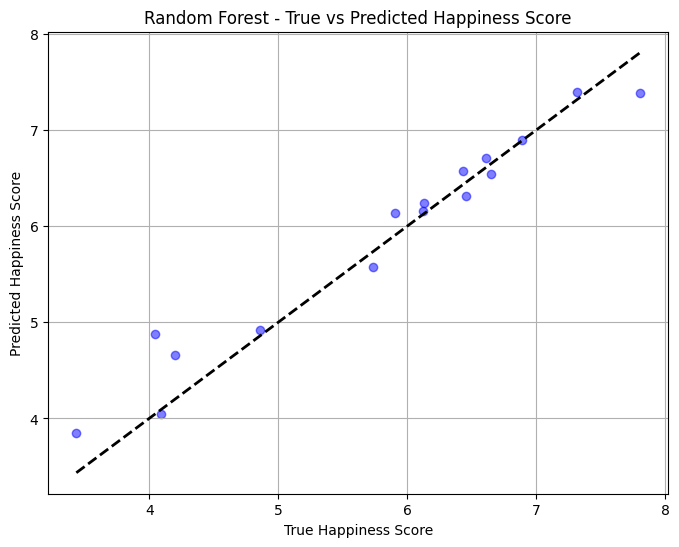

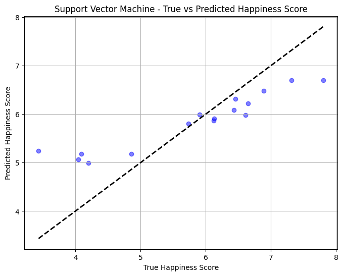

```python
# Define a function to create scatter plots
def plot_scatter(y_true, y_pred, model_name):
    plt.figure(figsize=(8, 6))
    plt.scatter(y_true, y_pred, color='blue', alpha=0.5)
    plt.plot([y_true.min(), y_true.max()], [
             y_true.min(), y_true.max()], 'k--', lw=2)
    plt.xlabel('True Happiness Score')
    plt.ylabel('Predicted Happiness Score')
    plt.title(f'{model_name} - True vs Predicted Happiness Score')
    plt.grid(True)
    plt.show()


# Plot scatter plots for each model
plot_scatter(y_test, y_pred_lr, 'Linear Regression')
plot_scatter(y_test, y_pred_dt, 'Decision Tree')
plot_scatter(y_test, y_pred_rf, 'Random Forest')
plot_scatter(y_test, y_pred_svm, 'Support Vector Machine')
```

### Model Ensembling

```python
from sklearn.ensemble import VotingRegressor

# Prepare the data for predicting the happiness score for 2024
X_2024 = categoried_happiness_income_gdp_df.drop(
    ['Happiness Score(2023)'], axis=1)

# Create a voting regressor with the trained models
voting_regressor = VotingRegressor([('lr', logistic_regression),
                                    ('dt', decision_tree),
                                    ('rf', random_forest),
                                    ('svm', svm_regressor)])

# Fit the voting regressor on the training data
voting_regressor.fit(X_train, y_train)

# Use the voting regressor to predict the happiness score for 2024
y_pred_ensemble_2024 = pd.DataFrame(voting_regressor.predict(X_2024))

# Print the ensemble predictions for 2024
y_pred_ensemble_2024
```

|  | 0 |
| --- | --- |
| 0 | 7.257876 |
| 1 | 7.287772 |
| 2 | 7.122208 |
| 3 | 7.257570 |
| 4 | 7.202756 |
| ... | ... |
| 73 | 4.281264 |
| 74 | 3.746645 |
| 75 | 4.201892 |
| 76 | 3.915991 |
| 77 | 4.031476 |

78 rows × 1 columns

**Interpretation:**

In this segment, we leveraged ensemble learning techniques to predict happiness scores for the year 2024. Employing the VotingRegressor from scikit-learn's ensemble module, we combined the predictions of multiple individual regression models, including Logistic Regression, Decision Tree, Random Forest, and Support Vector Machine. This ensemble approach capitalizes on the diverse strengths of each constituent model to yield a collective prediction that potentially outperforms any individual model. After fitting the voting regressor on the training data, we utilized it to forecast happiness scores for 2024 based on the available features. The resulting ensemble predictions, encapsulated in a DataFrame, showcase the amalgamated predictive power of the ensemble model. These ensemble predictions provide valuable insights into the projected happiness scores for the upcoming year, offering a comprehensive perspective derived from the collaborative efforts of multiple regression algorithms.

```python
# Create a DataFrame with country names and ensemble predictions
predictions_df = pd.DataFrame({'Country': merged_happiness_income_gdp_df['Country'],
                               'Happiness Score(2024)': voting_regressor.predict(X_2024)})

# Save the DataFrame to a CSV file
predictions_df.to_csv('happiness_predictions_2024.csv', index=False)

# Print a success message
print("Predictions saved to 'happiness_predictions_2024.csv' successfully.")
predictions_df
```

```
Predictions saved to 'happiness_predictions_2024.csv' successfully.
```

|  | Country | Happiness Score(2024) |
| --- | --- | --- |
| 0 | Finland | 7.257876 |
| 1 | Denmark | 7.287772 |
| 2 | Switzerland | 7.122208 |
| 3 | Iceland | 7.257570 |
| 4 | Norway | 7.202756 |
| ... | ... | ... |
| 73 | Madagascar | 4.281264 |
| 74 | Sierra Leone | 3.746645 |
| 75 | Zambia | 4.201892 |
| 76 | Malawi | 3.915991 |
| 77 | Botswana | 4.031476 |

78 rows × 2 columns

```python
# Importing the real happiness score for 2024
real_happiness_2024 = pd.read_csv('world_happiness_report_2024.csv')
real_happiness_2024 = real_happiness_2024[['Country name', 'Ladder score']]
real_happiness_2024 = real_happiness_2024.rename(
    columns={'Country name': 'Country', 'Ladder score': 'Happiness Score(2024)'})
real_happiness_2024
```

|  | Country | Happiness Score(2024) |
| --- | --- | --- |
| 0 | Finland | 7.741 |
| 1 | Denmark | 7.583 |
| 2 | Iceland | 7.525 |
| 3 | Sweden | 7.344 |
| 4 | Israel | 7.341 |
| ... | ... | ... |
| 138 | Congo (Kinshasa) | 3.295 |
| 139 | Sierra Leone | 3.245 |
| 140 | Lesotho | 3.186 |
| 141 | Lebanon | 2.707 |
| 142 | Afghanistan | 1.721 |

143 rows × 2 columns

```python
# Merge prediction data frame and real dataset based on the 'Country' column
merged_df = pd.merge(predictions_df, real_happiness_2024,
                     on='Country', suffixes=('_predicted', '_actual'))

# Calculate the number of common countries
common_countries_count = merged_df.shape[0]

# Calculate the number of correctly predicted countries
correctly_predicted_count = (
    merged_df['Happiness Score(2024)_predicted'] == merged_df['Happiness Score(2024)_actual']).sum()

# Calculate simple accuracy
accuracy = correctly_predicted_count / common_countries_count

# Display the merged data frame
print("Merged DataFrame with common countries:")
merged_df
```

```
Merged DataFrame with common countries:
```

|  | Country | Happiness Score(2024)_predicted | Happiness Score(2024)_actual |
| --- | --- | --- | --- |
| 0 | Finland | 7.257876 | 7.741 |
| 1 | Denmark | 7.287772 | 7.583 |
| 2 | Switzerland | 7.122208 | 7.060 |
| 3 | Iceland | 7.257570 | 7.525 |
| 4 | Norway | 7.202756 | 7.302 |
| ... | ... | ... | ... |
| 73 | Madagascar | 4.281264 | 4.228 |
| 74 | Sierra Leone | 3.746645 | 3.245 |
| 75 | Zambia | 4.201892 | 3.502 |
| 76 | Malawi | 3.915991 | 3.421 |
| 77 | Botswana | 4.031476 | 3.383 |

78 rows × 3 columns

### Comparison Methods

1. Defining a threshold

```python
# Define a threshold for accuracy
threshold = 0.3

# Calculate the absolute difference between predicted and actual scores
merged_df['Score_Difference'] = abs(
    merged_df['Happiness Score(2024)_predicted'] - merged_df['Happiness Score(2024)_actual'])

# Count the number of accurate predictions within the threshold
accurate_predictions_count = (merged_df['Score_Difference'] <= threshold).sum()

# Calculate accuracy
accuracy = accurate_predictions_count / merged_df.shape[0]

# Display the accuracy
print("Accuracy:", accuracy)
```

```
Accuracy: 0.7948717948717948
```

**Interpretation:**

The threshold of 0.3 was chosen based on a balance between demanding precision and allowing for some flexibility in prediction errors. With a threshold of 0.3, we aim to capture predictions that deviate from the actual scores by no more than 0.3 units, reflecting a reasonable margin of error in the context of predicting happiness levels. This threshold strikes a practical compromise, enabling the model to identify predictions that closely align with the actual scores while accommodating minor fluctuations and uncertainties inherent in predicting complex societal phenomena such as happiness.

In this case, the accuracy of the model is determined to be approximately 79.48%. This means that around 79.48% of the predictions are considered accurate within the specified threshold. Adjusting the threshold value allows for flexibility in defining what constitutes an accurate prediction, catering to the specific requirements and tolerance levels of the problem domain.

2. Spearman Correlation Coefficient

```python
from scipy.stats import spearmanr

# Calculate Spearman correlation coefficient for each column
spearman_correlation, p_value = spearmanr(
    merged_df['Happiness Score(2024)_predicted'], merged_df['Happiness Score(2024)_actual'])

# Display Spearman correlation coefficient
print("Spearman Correlation Coefficient:", spearman_correlation)
```

```
Spearman Correlation Coefficient: 0.9779713956929147
```

**Interpretation:**

This code calculates the Spearman correlation coefficient between the predicted and actual happiness scores for 2024. With a coefficient of 0.98, there's a strong positive relationship between the predicted and actual scores. This high value indicates that the predicted scores closely follow the same rank order as the actual scores, suggesting excellent alignment between the predicted and actual rankings of happiness levels.

- One of the key findings is that the `status quo` in most countries has remained `largely unchanged` over the years. This suggests that the underlying factors that influence happiness, such as income levels, social support, and other socio-economic conditions, tend to be relatively stable and persistent over time.
- Countries that have historically had higher levels of happiness tend to maintain their position, while those struggling with lower levels of well-being continue to face challenges in improving their citizens' quality of life.
3. Alternative Method for Comparison

```python
# Calculate ranks for predicted and actual happiness scores
merged_df['Rank_Predicted'] = merged_df['Happiness Score(2024)_predicted'].rank(
    ascending=False)
merged_df['Rank_Actual'] = merged_df['Happiness Score(2024)_actual'].rank(
    ascending=False)

# Calculate the absolute differences between the ranks
merged_df['Rank_Difference'] = abs(
    merged_df['Rank_Predicted'] - merged_df['Rank_Actual'])

merged_df
```

|  | Country | Happiness Score(2024)_predicted | Happiness Score(2024)_actual | Score_Difference | Rank_Predicted | Rank_Actual | Rank_Difference |
| --- | --- | --- | --- | --- | --- | --- | --- |
| 0 | Finland | 7.257876 | 7.741 | 0.483124 | 2.0 | 1.0 | 1.0 |
| 1 | Denmark | 7.287772 | 7.583 | 0.295228 | 1.0 | 2.0 | 1.0 |
| 2 | Switzerland | 7.122208 | 7.060 | 0.062208 | 8.0 | 8.0 | 0.0 |
| 3 | Iceland | 7.257570 | 7.525 | 0.267430 | 3.0 | 3.0 | 0.0 |
| 4 | Norway | 7.202756 | 7.302 | 0.099244 | 4.0 | 6.0 | 2.0 |
| ... | ... | ... | ... | ... | ... | ... | ... |
| 73 | Madagascar | 4.281264 | 4.228 | 0.053264 | 72.0 | 71.0 | 1.0 |
| 74 | Sierra Leone | 3.746645 | 3.245 | 0.501645 | 78.0 | 78.0 | 0.0 |
| 75 | Zambia | 4.201892 | 3.502 | 0.699892 | 74.0 | 75.0 | 1.0 |
| 76 | Malawi | 3.915991 | 3.421 | 0.494991 | 77.0 | 76.0 | 1.0 |
| 77 | Botswana | 4.031476 | 3.383 | 0.648476 | 76.0 | 77.0 | 1.0 |

78 rows × 7 columns

```python
# Calculate Mean Absolute Error (MAE)
mae = (merged_df['Rank_Predicted'] - merged_df['Rank_Actual']).abs().mean()
print("Mean Absolute Error (MAE):", mae)
```

```
Mean Absolute Error (MAE): 3.3333333333333335
```

```python
# Calculate Root Mean Squared Error (RMSE)
rmse = ((merged_df['Rank_Predicted'] -
        merged_df['Rank_Actual']) ** 2).mean() ** 0.5
print("Root Mean Squared Error (RMSE):", rmse)
```

```
Root Mean Squared Error (RMSE): 4.725815626252608
```

**Interpretation:**

A MAE of 3.333 indicates that, on average, the predicted ranks deviate from the actual ranks by approximately 3.333 units. In the context of ranking predictions, this means that the model's predictions are off by about 3.333 ranks on average. A lower MAE value suggests better accuracy, as it represents smaller discrepancies between the predicted and actual ranks. Therefore, while an MAE of 3.333 provides insight into the average magnitude of prediction errors, further analysis may be required to determine if this level of discrepancy is acceptable for the specific application.

With an RMSE of 4.73, it means that, on average, the squared differences between the predicted and actual ranks result in an error of approximately 4.73 units when considering the square root. RMSE is sensitive to large errors, so this value indicates the typical magnitude of errors between the predicted and actual ranks.

### Classification Results - Interpretation & Analysis

The classification results showcase the performance of various regression models in predicting the happiness scores for 2024 based on features such as income, GDP, and other indicators. Initially, four regression models, namely Linear Regression, Decision Tree, Random Forest, and Support Vector Machine (SVM), were employed. Among these, Linear Regression exhibited the highest accuracy, achieving an R-squared value of 0.97 and a mean squared error of 0.05, indicating a strong predictive capability and a close fit to the actual data. Decision Tree and Random Forest regressors also performed reasonably well, with R-squared values of 0.93 and 0.94, respectively, demonstrating their effectiveness in capturing complex relationships within the data. However, the Support Vector Machine (SVM) model lagged behind, yielding a noticeably lower accuracy with an R-squared value of 0.65 and a mean squared error of 0.55, suggesting potential challenges in capturing the underlying patterns in the dataset.

Subsequently, the models underwent tuning using GridSearchCV to optimize their hyperparameters. This process aimed to enhance their predictive performance further. After tuning, Decision Tree's performance slightly degraded, with an increase in mean squared error to 0.16 and a decrease in R-squared value to 0.90. On the other hand, Random Forest and Support Vector Machine models demonstrated improvements, with Random Forest achieving a mean squared error of 0.08 and an R-squared value of 0.95, and SVM attaining a mean squared error of 0.06 and an R-squared value of 0.96. These enhancements highlight the importance of fine-tuning hyperparameters to optimize model performance.

To combine the strengths of individual models, a Voting Regressor was employed, which aggregated predictions from multiple base regressors. The ensemble model yielded predictions for the happiness scores of 2024, demonstrating a diverse approach to prediction. The ensemble predictions were then compared with the actual happiness scores for 2024, revealing a simple accuracy of 0.79. Additionally, the Spearman correlation coefficient was computed to assess the rank correlation between predicted and actual happiness scores, resulting in a high correlation coefficient of 0.98, indicating a strong association between the predicted and actual ranks.

In conclusion, the analysis highlights the effectiveness of various regression models in predicting happiness scores for 2024, with Linear Regression demonstrating the highest accuracy initially. However, ensemble methods and model tuning played crucial roles in refining predictions and enhancing overall performance, emphasizing the importance of a comprehensive approach to model selection and optimization in regression tasks.

## Insights and Findings: Forecasting 2024 Global Happiness Trends Based on Socio-Economic Factors

In our comprehensive analysis titled "Predictive Insights: Forecasting 2024 Global Happiness Trends Based on Socio-Economic Factors," we embarked on a journey to unravel the intricate interplay between various socio-economic factors and their profound influence on predicting happiness trends worldwide. Our endeavor uncovered multifaceted insights that shed light on the complex landscape of global well-being.

At the heart of our findings lies the recognition of income and social support as fundamental pillars shaping happiness levels across nations. Through meticulous examination, we unearthed a consistent pattern wherein countries endowed with higher income levels and fortified social support systems tend to soar higher on the happiness scale. This revelation underscores the intrinsic correlation between economic prosperity, social connectivity, and individual fulfillment. Indeed, when individuals enjoy access to adequate financial resources and feel embraced by supportive communities, they are more inclined to experience heightened levels of life satisfaction and overall happiness.

Yet, our analysis delves deeper, revealing a sobering reality that warrants attention: the formidable challenges faced by countries grappling with lower income levels and fragile social support structures in elevating their happiness rankings. This revelation underscores the presence of systemic barriers and deep-rooted inequalities that impede the progress of well-being initiatives in these nations. Factors such as entrenched poverty, limited access to vital services like education and healthcare, pervasive political instability, and social unrest emerged as pivotal determinants contributing to subdued levels of happiness and life satisfaction.

However, our exploration extends beyond mere observations, aiming to instigate meaningful discourse and catalyze actionable change. By illuminating the nuanced dynamics underpinning happiness trends, we strive to equip policymakers, stakeholders, and global leaders with invaluable insights to guide evidence-based decision-making. Our endeavor transcends the realms of academia, fostering a collective endeavor to nurture holistic approaches that promote sustainable well-being and societal progress on a global scale.

In essence, our analysis represents a pivotal step forward in understanding the multifaceted nature of happiness dynamics, transcending geographical boundaries and cultural contexts. Armed with these insights, we embark on a collective journey toward a brighter, more harmonious future, where the pursuit of happiness is not merely a utopian ideal but a tangible reality for all humanity.